# Keertana Vajjhala

Computer Architecture · ASIC Design · Digital IC · SoC Verification

Graduate student at the University of Illinois Urbana-Champaign (MEng ECE, Dec 2026), with 2+ years of industry experience designing and verifying ASIC silicon at Samsung Semiconductors. I work at the intersection of RTL design, microarchitecture, and SoC verification — building hardware that has to work the first time.

Experience ↓ Projects ↓ keertanavajjhala@gmail.com [LinkedIn ↗](https://linkedin.com/in/vajjhala-keertana-b20286211) [GitHub ↗](https://github.com/VajjhalaKeertana)

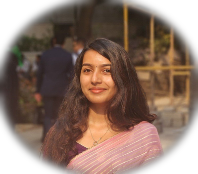

Skills

Computer Architecture

Microarchitecture OoO Execution Pipelining RISC-V Memory Systems CUDA / Parallel Programming

ASIC & VLSI

RTL Design Logic Synthesis Place & Route Timing Analysis Synopsys Design Compiler Cadence Virtuoso Standard Cell Layout Power Analysis

Digital IC Design

SystemVerilog Verilog VHDL FPGA Xilinx Vivado PCIe NVMe AXI AHB UFS 4.0

Verification

UVM Functional Verification Formal Verification DFT CDC LDRC Python C / C++

Experience & Education

Aug 2023 – Aug 2025

Samsung Semiconductors India Research

Senior Engineer · Bangalore, India

Designed and verified digital circuits in SystemVerilog for NVMe SSD controller ASICs targeting datacenter, client, and automotive platforms. Owned RTL implementation, AXI/AHB protocol integration, synthesis and timing closure in Synopsys Design Compiler, and full signoff (DFT lint, CDC, LDRC). Built and ran UVM testbenches for PCIe and NVMe functional verification. Ensured SRAM integrity and resolved race conditions through systematic debugging. Led latency reduction initiatives recognized with Samsung's SPOT award and Employee of the Month distinction.

Jan 2023 – Aug 2023

Samsung Semiconductors India Research

Hardware Intern · Bangalore, India

Designed embedded memory controllers and UFS 4.0 interface logic for the Samsung Galaxy S25 series using Verilog HDL and ASIC design methodologies. Developed UVM-based testbenches and performed functional verification and coverage analysis against design specifications.

May 2022 – Jul 2022

Center of Robotics and Innovation

Summer Intern · Funded by Neuberg Anand Labs

Programmed a 5-axis robotic arm control system for automated medical sample identification and sorting via barcode scanning in embedded C. Integrated hardware with Raspberry Pi; real-time control algorithms are currently deployed in diagnostic laboratory operations.

Expected Dec 2026

University of Illinois Urbana-Champaign

Master of Engineering, Electrical and Computer Engineering

Coursework: Computer Organization & Design (ECE411), Applied Parallel Programming / CUDA (ECE408), Logic Synthesis (ECE462), Introduction to VLSI (ECE425), Advanced Computer Architecture (ECE511).

Aug 2019 – Jun 2023

PES University, RR Campus · Bangalore

B.Tech, Electronics & Communication (VLSI) · GPA 8.58/10

MRD Scholarship — 40% merit award to top of class. Graduated with Distinction. Coursework: Advanced Digital Design, Digital VLSI, Verification of Digital Systems, Advanced Hardware Acceleration.

Projects

RISC-V Out-of-Order Processor

GitHub ↗

UIUC ECE411 · Nov – Dec 2025

Designed a full RV32I out-of-order processor in SystemVerilog featuring ERR-based register renaming, ROB, reservation stations, LSQ, and speculative execution. Built a 2-way superscalar pipeline with GSHARE branch prediction and misprediction recovery. Verified correctness through directed and random testbenches.

SystemVerilogRISC-VOoO ExecutionBranch Prediction

RISC-V32I Single-Cycle Datapath

In Progress

UIUC ECE425 · 2025–2026

Designing a bit-sliced RISC-V32I single-cycle processor datapath schematic and physical layout in Cadence Virtuoso, including full ALU and register file layouts. Applying Euler path-based diffusion string optimization for standard cells with LVS/DRC signoff.

Cadence VirtuosoVLSI LayoutLVS/DRCStandard Cells

DRAM Scheduling Policy Analysis

UIUC ECE511 · 2025

Implemented and evaluated custom DRAM scheduling policies in DRAMsim3, including XOR-based bank/bankgroup address interleaving and policies such as FR-FCFS, Oldest-First, Read-over-Write, and Idle-Bank-First. Benchmarked across FFT, LU, and RADIX traces.

DRAMsim3Memory ArchitecturePython

Refreshable Braille Display

IEEE Published

PES University · Jan – Dec 2022

Developed a portable Braille display for visually impaired users using servo motor control and embedded C on ESP32. Achieved 57.5% power reduction, 20°C temperature decrease, and 71.6% cost reduction while maintaining 3.6 Hz refresh rate. Published at IEEE ICONAT 2023.

Embedded CESP32Low-Power

Publications

Interactive Educational Device for the Visually Impaired Using Refreshable Braille Display

IEEE ICONAT 2023 — International Conference on Advancement in Nanoelectronics and Telecommunication

Keertana Vajjhala et al. · Available on IEEE Xplore

Contact

Open to internship and full-time opportunities in digital IC design, computer architecture, and SoC verification.

keertanavajjhala@gmail.com

LinkedIn

GitHub

Download Resume